# Barbell exercise correctness prediction

Stephen Gillanders

10/8/2017

## The Barbell data

A group of 6 participants performed barbell lifts correctly and incorrectly in 5 different ways. The data comes from the article on “Wearable Computing: Accelerometers’ Data Classification of Body Postures and Movements” in the [Proceedings of 21st Brazilian Symposium on Artificial Intelligence](http://web.archive.org/web/20161224072740/http:/groupware.les.inf.puc-rio.br/har). Please refer to the web link for details.

The goal of the following analysis is the accurate prediction of the type of exercise based on the measured variables. The variable “classe” reflects this outcome.

## Obtain Data

```r
if (!file.exists("./pml-training.csv")) {
    download.file("https://d396qusza40orc.cloudfront.net/predmachlearn/pml-training.csv","./pml-training.csv")
}
if (!file.exists("./pml-testing.csv")) {
    download.file("https://d396qusza40orc.cloudfront.net/predmachlearn/pml-testing.csv","./pml-testing.csv")
}
full_training <- read.csv("./pml-training.csv",header=TRUE,na.strings=c("NA","#DIV/0!"))
full_testing <- read.csv("./pml-testing.csv",header=TRUE,na.strings=c("NA","#DIV/0!"))
```

```
## [1] "Training set: 19622 observations of 160 variables"
```

```
## [1] "Testing set: 20 observations of 160 variables"
```

## R libraries

```r
library(randomForest)
library(caret)
library(plyr)
library(dplyr)
library(adabag)
library(knitr)
```

## Preliminary Exploration

```r
# Check for completeness of the data
sprintf("Number of complete cases in training set: %d",sum(complete.cases(full_training)))
```

```
## [1] "Number of complete cases in training set: 0"
```

```r
tNA <- apply(full_training,2,anyNA)
sprintf("Number of variables with one or more NA values: %d",sum(tNA))
```

```
## [1] "Number of variables with one or more NA values: 100"
```

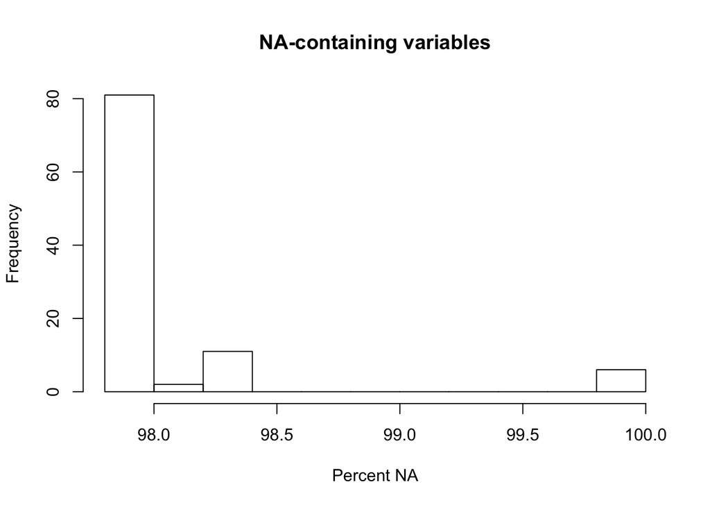

```r
tnNA <- apply(full_training[,tNA],2,function(x) 100*(sum(is.na(x))/dim(full_training)[1]))
hist(tnNA,main="NA-containing variables",xlab="Percent NA")
```

Visible in the plot above is that the 100 NA-containing variables are mostly >95% incomplete. It turns out that they are “summary” variables (eg. kurtosis, skewness, average…) and removing them from the set leaves “real observation variables”:

```
##  [1] "X"                    "user_name"            "raw_timestamp_part_1"
##  [4] "raw_timestamp_part_2" "cvtd_timestamp"       "new_window"
##  [7] "num_window"           "roll_belt"            "pitch_belt"
## [10] "yaw_belt"             "total_accel_belt"     "gyros_belt_x"
## [13] "gyros_belt_y"         "gyros_belt_z"         "accel_belt_x"
## [16] "accel_belt_y"         "accel_belt_z"         "magnet_belt_x"
## [19] "magnet_belt_y"        "magnet_belt_z"        "roll_arm"
## [22] "pitch_arm"            "yaw_arm"              "total_accel_arm"
## [25] "gyros_arm_x"          "gyros_arm_y"          "gyros_arm_z"
## [28] "accel_arm_x"          "accel_arm_y"          "accel_arm_z"
## [31] "magnet_arm_x"         "magnet_arm_y"         "magnet_arm_z"
## [34] "roll_dumbbell"        "pitch_dumbbell"       "yaw_dumbbell"
## [37] "total_accel_dumbbell" "gyros_dumbbell_x"     "gyros_dumbbell_y"
## [40] "gyros_dumbbell_z"     "accel_dumbbell_x"     "accel_dumbbell_y"
## [43] "accel_dumbbell_z"     "magnet_dumbbell_x"    "magnet_dumbbell_y"
## [46] "magnet_dumbbell_z"    "roll_forearm"         "pitch_forearm"
## [49] "yaw_forearm"          "total_accel_forearm"  "gyros_forearm_x"
## [52] "gyros_forearm_y"      "gyros_forearm_z"      "accel_forearm_x"
## [55] "accel_forearm_y"      "accel_forearm_z"      "magnet_forearm_x"
## [58] "magnet_forearm_y"     "magnet_forearm_z"     "classe"
```

as when and who should not be important in predicting the type of exercise.

```r
# Select only the variables of interest
full_training <- select(full_training,nm[!tNA])
# remove also the when and who variables
full_training <- select(full_training,-c(1:6))
# repeat for test data
nmt <- names(full_testing)
testNA <- apply(full_testing,2,anyNA)
full_testing <- select(full_testing,nmt[!testNA])
full_testing <- select(full_testing,-c(1:6))
```

There are no “near zero variance” variables as evidenced by:

```r
nearZeroVar(full_training)
```

```
## integer(0)
```

The full training data set now consists of 19622 complete observations.

```r
# divide the training data into a training and testing and cross-validation set.
set.seed(1234)
trainIndex <- createDataPartition(full_training$classe,p=0.6,list=FALSE)
pmlTraining <- full_training[trainIndex,]
otherTemp <- full_training[-trainIndex,]
cvIndex <- createDataPartition(otherTemp$classe,p=0.5,list=FALSE)
pmlTesting <- otherTemp[cvIndex,]
pmlCrossValidation <- otherTemp[-cvIndex,]
```

```r
# Separate out the outcome
pmlTrClasse <- pmlTraining[,"classe"]
pmlTeClasse <- pmlTesting[,"classe"]
pmlCvClasse <- pmlCrossValidation[,"classe"]
pmlTraining <- select(pmlTraining,-classe)
pmlTesting <- select(pmlTesting,-classe)
pmlCrossValidation <- select(pmlCrossValidation,-classe)
```

## Model building

First, a model based on simple decision trees:

```r
mtrees <- train(pmlTraining,pmlTrClasse,method="rpart")
mtreesTrClasse <- factor(max.col(predict(mtrees$finalModel,newdata=pmlTraining)),levels=c(1,2,3,4,5),labels=c("A","B","C","D","E"))
mtreesTeClasse <- factor(max.col(predict(mtrees$finalModel,newdata=pmlTesting)),levels=c(1,2,3,4,5),labels=c("A","B","C","D","E"))
mtreesCM <- confusionMatrix(mtreesTeClasse,pmlTeClasse)
mtreesCM$overall ; mtreesCM$table
```

```
##       Accuracy          Kappa  AccuracyLower  AccuracyUpper   AccuracyNull
##   4.878919e-01   3.305745e-01   4.721368e-01   5.036651e-01   2.844762e-01
## AccuracyPValue  McnemarPValue
##  5.809348e-159            NaN
```

```
##           Reference
## Prediction    A    B    C    D    E
##          A 1009  311  329  285  110
##          B   15  253   29  109  104
##          C   91  195  326  249  181
##          D    0    0    0    0    0
##          E    1    0    0    0  326
```

Lets see if this can be improved. Next a random forest model

```r
mrf <- randomForest(pmlTraining,pmlTrClasse)
mrfTrClasse <- predict(mrf,newdata=pmlTraining)
mrfTeClasse <- predict(mrf,newdata=pmlTesting)
mrfCM <- confusionMatrix(mrfTeClasse,pmlTeClasse)
mrfCM$overall ; mrfCM$table
```

```
##       Accuracy          Kappa  AccuracyLower  AccuracyUpper   AccuracyNull
##      0.9956666      0.9945182      0.9930708      0.9974737      0.2844762
## AccuracyPValue  McnemarPValue
##      0.0000000            NaN
```

```
##           Reference
## Prediction    A    B    C    D    E
##          A 1116    3    0    0    0
##          B    0  755    2    0    0
##          C    0    1  681    7    0
##          D    0    0    1  635    2
##          E    0    0    0    1  719
```

Great, accuracy improves.

Lets try adaptive boosting:

```r
madab <- boosting(pmlTrClasse~.,data=cbind(pmlTraining,pmlTrClasse),mfinal=100)
madabTrClasse <- factor(max.col(predict(madab,newdata=pmlTraining)$prob),levels=c(1,2,3,4,5),labels=c("A","B","C","D","E"))
madabTeClasse <- factor(max.col(predict(madab,newdata=pmlTesting)$prob),levels=c(1,2,3,4,5),labels=c("A","B","C","D","E"))
madabCM <- confusionMatrix(madabTeClasse,pmlTeClasse)
madabCM$overall ; madabCM$table
```

```
##       Accuracy          Kappa  AccuracyLower  AccuracyUpper   AccuracyNull
##      0.9969411      0.9961307      0.9946628      0.9984185      0.2844762
## AccuracyPValue  McnemarPValue
##      0.0000000            NaN
```

```
##           Reference
## Prediction    A    B    C    D    E
##          A 1116    2    0    0    0
##          B    0  757    0    0    0
##          C    0    0  682    7    0
##          D    0    0    2  636    1
##          E    0    0    0    0  720
```

Similar performance as random forest.

Now a stacked model which we train on the testing set and test on the cross validation set:

```r
pmlCombTraining <- data.frame(rpart=mtreesTrClasse,rf=mrfTrClasse,adab=madabTrClasse)
pmlCombTesting <- data.frame(rpart=mtreesTeClasse,rf=mrfTeClasse,adab=madabTeClasse)
pmlCombCv <- data.frame(
                rpart=factor(max.col(
                        predict(mtrees$finalModel,
                            newdata=pmlCrossValidation)),
                        levels=c(1,2,3,4,5),labels=c("A","B","C","D","E")),
                rf=predict(mrf,newdata=pmlCrossValidation),
                adab=factor(max.col(
                    predict(madab,
                            newdata=pmlCrossValidation)$prob),
                    levels=c(1,2,3,4,5),labels=c("A","B","C","D","E"))
            )
finalModel <- train(pmlCombTesting,pmlTeClasse,method="rf")
combCM <- confusionMatrix(predict(finalModel,pmlCombCv),pmlCvClasse)
combCM$overall ; combCM$table
```

```
##       Accuracy          Kappa  AccuracyLower  AccuracyUpper   AccuracyNull
##      0.9977058      0.9970982      0.9956495      0.9989504      0.2844762
## AccuracyPValue  McnemarPValue
##      0.0000000            NaN
```

```
##           Reference
## Prediction    A    B    C    D    E
##          A 1116    0    0    0    0
##          B    0  759    0    0    1
##          C    0    0  682    4    0
##          D    0    0    2  638    1
##          E    0    0    0    1  719
```

Excellent accuracy now. The expectation is that the out of sample error will be less than half a percent (< 0.5%).

To apply the model to the actual testing observations:

```r
combined_test_data <- data.frame(
                rpart=factor(max.col(
                        predict(mtrees$finalModel,
                            newdata=full_testing)),
                        levels=c(1,2,3,4,5),labels=c("A","B","C","D","E")),
                rf=predict(mrf,newdata=full_testing),
                adab=factor(max.col(
                    predict(madab,
                            newdata=full_testing)$prob),
                    levels=c(1,2,3,4,5),labels=c("A","B","C","D","E")),
                problem_id=full_testing$problem_id
            )
df <- data.frame(problem_id=full_testing$problem_id,
                 prediction=predict(finalModel,combined_test_data))
# kable(df)
```